# Simple linear regression homework - solutions

# 1 MVP

The file `project_management.csv` contains data sampled from the recent work schedule of a small construction company. Column `estimated_length` contains the estimated length of a building job in days, while column `actual_length` contains the actual recorded length of the job in days.

We are interested in determining the accuracy of the job estimations made by the company using simple linear regression, so we will eventually want to run a **simple linear regression** using `actual_length` as the dependent variable, and `estimated_length` as the independent variable.

- Load the data into a dataframe `project`

```r
library(tidyverse)
project <- read_csv('data/project_management.csv')
```

```
## * `` -> ...1
```

- Plot the data, taking `estimated_length` as the independent variable and `actual_length` as the dependent variable.

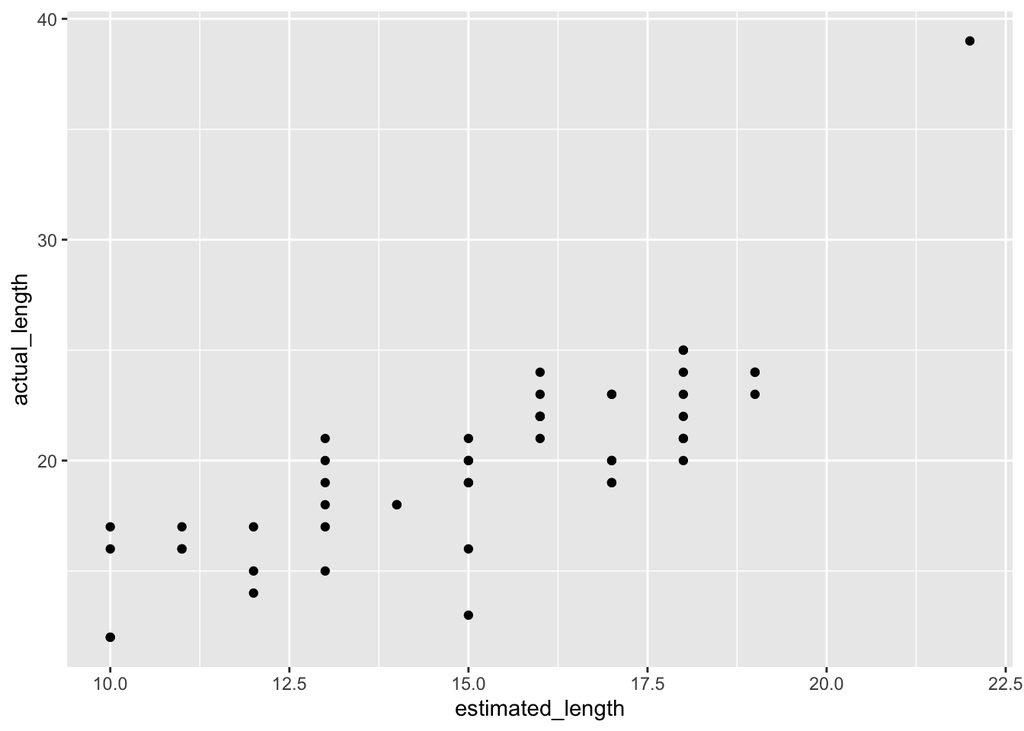

```r
plot <- project %>%
  ggplot(aes(x = estimated_length, y = actual_length)) +
  geom_point()

plot
```

- Calculate the correlation coefficient of `estimated_length` and `actual_length` and interpret the value you obtain.

```r
project %>%
  summarise(corr_coeff = cor(estimated_length, actual_length))
```

| corr_coeff |
| --- |
| 0.8046597 |

So we find a very strong positive correlation between the two variables.

- Perform a simple linear regression using `actual_length` as the dependent variable, and `estimated_length` as the independent variable. Save the model object to a variable.

```r
model <- lm(actual_length ~ estimated_length, data = project)
```

- Interpret the regression coefficient of `estimated_length` (i.e. slope, gradient) you obtain from the model. How do you interpret the $r^2$ value reported by the model?

```r
summary(model)
```

```
##
## Call:
## lm(formula = actual_length ~ estimated_length, data = project)
##
## Residuals:
##     Min      1Q  Median      3Q     Max
## -6.7687 -1.6513  0.1195  1.1252 10.6669
##
## Coefficients:
##                  Estimate Std. Error t value Pr(>|t|)
## (Intercept)        1.4164     2.0069   0.706    0.484
## estimated_length   1.2235     0.1303   9.389 1.91e-12 ***
## ---
## Signif. codes:  0 '***' 0.001 '**' 0.01 '*' 0.05 '.' 0.1 ' ' 1
##
## Residual standard error: 2.606 on 48 degrees of freedom
## Multiple R-squared:  0.6475, Adjusted R-squared:  0.6401
## F-statistic: 88.16 on 1 and 48 DF,  p-value: 1.911e-12
```

The regression equation is:

$$\widehat{\textrm{actual_length}} = 1.4164 + 1.2235 \times \textrm{estimated_length}$$
so a $1$ day increase in `estimated_length` is associated with a $1.2235$ day increase in `actual_length`, i.e. the company is underestimating job lengths.

The $r^2$ value tells us that approximately $65\%$ of the variation in `actual_length` can be predicted from the variation in `estimated_length`.

- Is the relationship statistically significant? Remember, to assess this you need to check the $p$-value of the regression coefficient (or slope/gradient). But you should first check the regression diagnostic plots to see if the $p$-value will be reliable (don’t worry about any outlier points you see in the diagnostic plots, we’ll return to them in the extension).

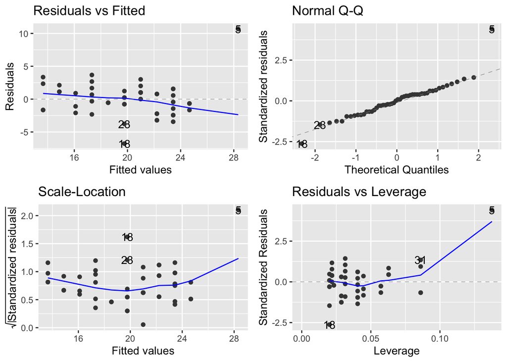

```r
library(ggfortify)
autoplot(model)
```

Aside from outliers (certainly point $5$, and perhaps point $18$), the diagnostic plots looks reasonable. The ‘Residuals vs Fitted’ plot reveals independent residuals, the ‘Normal Q-Q’ plot looks fine, and there is no systematic upward or downward trend in the the ‘Scale-Location’ plot.

The relationship is statistically significant, as the $p$-value of the slope is much less than a typical $\alpha$ of $0.05$.

# 2 Extension - Residuals vs Leverage

- Read [this material](https://boostedml.com/2019/03/linear-regression-plots-residuals-vs-leverage.html) on the **leverage** of points in regression, and how to interpret the `Residuals vs Leverage` diagnostic plot produced by plotting the `lm()` model object. So far we’ve been using the `autoplot()` function to plot the model objects produced by `lm()`, but you can see the base `R` equivalent by doing something like `plot(model)` where `model` is an `lm()` object.
- Return to your plot from earlier, and now label the data points with their row number in the data frame using `geom_text()` [**Hint** - you can pass `aes(label = 1:nrow(project))` to this layer to generate row index labels]
  - Identify by eye any points you think might be outliers and note their labels.
  - Further split your outliers into those you think are ‘influential’ or ‘non-influential’ based on a visual assessment of their leverage.

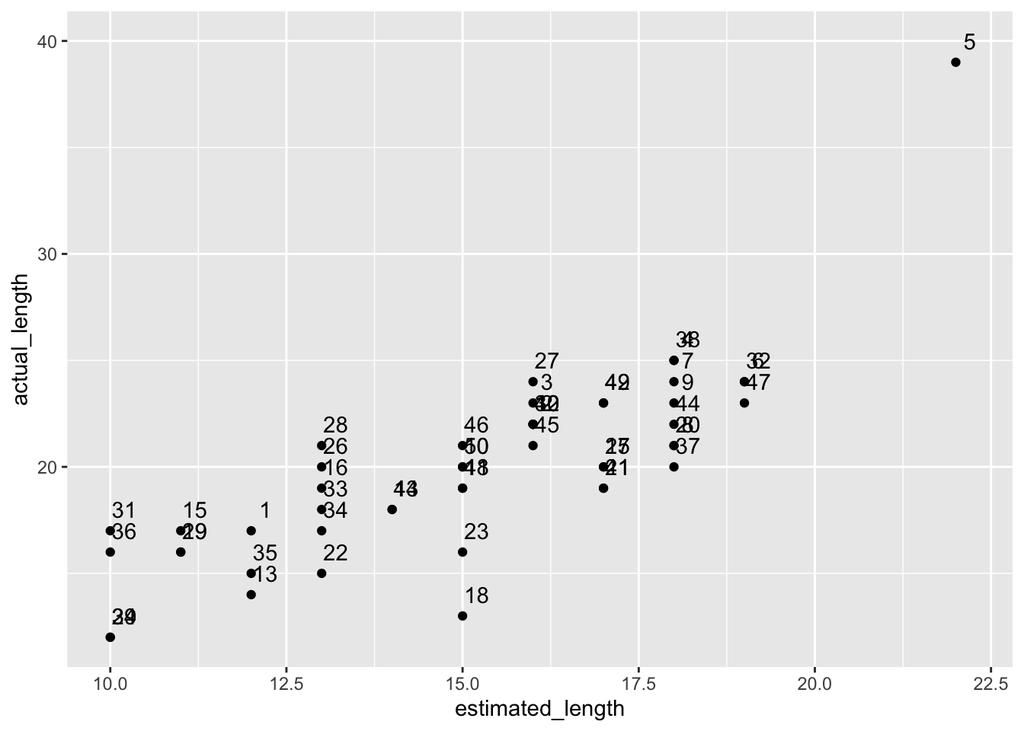

```r
plot <- plot +
  geom_text(aes(label = 1:nrow(project)), nudge_x = 0.2, nudge_y = 1)
plot
```

Some of the labels overlap, but that’s OK as we’re looking for outliers, which are likely to occur in isolation. Points $5$ and $18$ both look like outliers, and we might predict point $5$ to be ‘influential’ as it has high leverage, and point $18$ to be ‘non-influential’ given it has low leverage.

- Use your model object from earlier and confirm your visual assessment of which points are ‘influential’ or ‘non-influential’ outliers based on Cook’s distance. You can get a useful plot of Cook’s distance by passing argument `which = 4` to `autoplot()`. Or try the base `R` `plot()` function for comparison [e.g. `plot(model)`; you can also use `par(mfrow = c(2,2))` just before the `plot()` command to get a nice two-by-two display]!

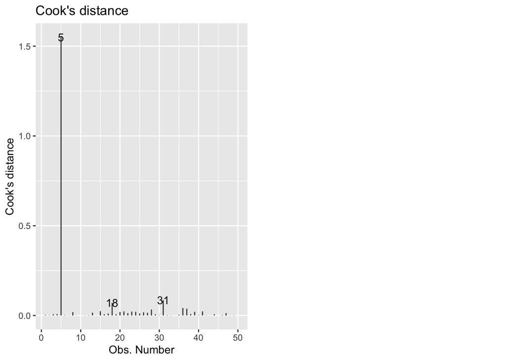

```r
autoplot(model, which = 4)
```

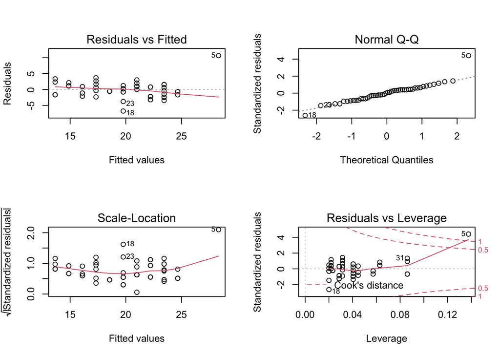

```r
par(mfrow = c(2,2))
plot(model)
```

The Cook’s distance plot confirms that point $5$ is an ‘influential’ outlier, as it lies above $1$. In fact, this threshold is rather arbitrary, a better method is to look to see if any observation has a Cook’s distance **substantially greater** than the others. If so, examine that observation. So we would definitely want to look again at the data gathered and the estimation process for the job on row 5 to see if any errors were made.

Point $18$ is an outlier, but is ‘non-influential’, as it has a Cook’s distance similar to the other points.

- Obtain the intercept and regression coefficient of variable `estimated_length` for a simple linear model fitted to data **omitting one of your non-influential outlier points**.
  - How different are the intercept and coefficient from those obtained above by fitting the full data set? Does this support classifying the omitted point as non-influential?

```r
omit_18 <- project %>%
  slice(-18)

omit_18_model <- lm(actual_length ~ estimated_length, data = omit_18)
omit_18_model
```

```
##
## Call:
## lm(formula = actual_length ~ estimated_length, data = omit_18)
##
## Coefficients:
##      (Intercept)  estimated_length
##            1.591             1.221
```

The intercepts differ by $0.175$ in $1.416$, i.e. by $12\%$. The coefficients differ by only $0.002$ in $1.223$, i.e. by $0.2\%$. These support classifying this point as ‘non-influential’.

- Plot the data points, this regression line and the regression line for the full data set. How different are the lines?

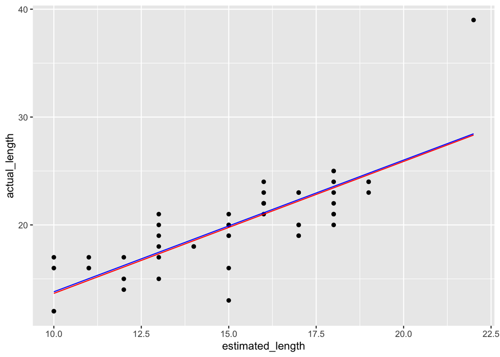

```r
library(modelr)

project <- project %>%
  add_predictions(model, var = "full_model_pred") %>%
  add_predictions(omit_18_model, var = "omit_18_model_pred")

project %>%
  ggplot(aes(x = estimated_length)) +
  geom_point(aes(y = actual_length)) +
  geom_line(aes(y = full_model_pred), col = "red") +
  geom_line(aes(y = omit_18_model_pred), col = "blue")
```

The regression line lacking point $18$ is slightly shifted upward, but it’s difficult to distinguish the two lines!

- Repeat the procedure above, but this time **omitting one of your influential outliers**.

```r
omit_5 <- project %>%
  slice(-5)

omit_5_model <- lm(actual_length ~ estimated_length, data = omit_5)
omit_5_model
```

```
##
## Call:
## lm(formula = actual_length ~ estimated_length, data = omit_5)
##
## Coefficients:
##      (Intercept)  estimated_length
##            4.381             1.011
```

The intercepts differ by $2.965$ in $1.416$, i.e. by $209\%$. The coefficients differ by $0.212$ in $1.223$, i.e. by $17\%$. Omitting this point leads to much larger differences in the regression parameters than the omission of point $18$, and justify labelling point $5$ as an influential outlier.

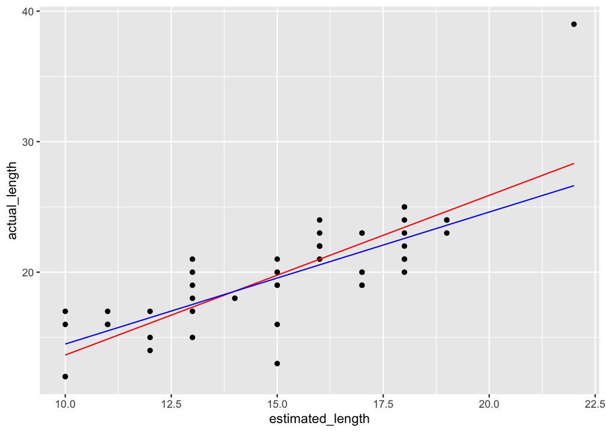

```r
project <- project %>%
  add_predictions(omit_5_model, var = "omit_5_model_pred")

project %>%
  ggplot(aes(x = estimated_length)) +
  geom_point(aes(y = actual_length)) +
  geom_line(aes(y = full_model_pred), col = "red") +
  geom_line(aes(y = omit_5_model_pred), col = "blue")
```

The two regression lines differ significantly! It is clear how the presence of point $5$ ‘drags’ the best fit line upward to steeper gradient.

# 3 Additional resources

- There are various techniques to perform what is known as ‘robust regression’ on a dataset. Robust methods are less affected by the presence of outliers. See the `rlm()` function (‘robust linear model’) in the `MASS` package and [this](http://www.alastairsanderson.com/R/tutorials/robust-regression-in-R/) blog post.